# Finances of a leader:

4 Things:

1. Budgets
2. Envelopes
3. Saving
4. Tips

The BEST way to manage your finances for God.

# Budget

4 Walls: Where you live, food, clothing, tithing. Tithing should come first.

Write in: how much do you get a month? Consider - take %10 right off of it and give it to God.

You’re not putting money in God’s wallet when you tithe. It’s all God’s money. So when you take any money out for yourself, you’re actually taking it out of God’s wallet.

Automatically deposit 10% of your money into your savings account.

Set a food budget/budget on the line items that can blow out of proportion. $300/month is a good budget for an individual for food.

# Envelopes

Are there things you spend money on emotionally? Use **envelopes**.

Money can be an incredibly emotional thing.

For Carol and James - food, clothes, gifts, entertainment.

Are gifts challenging? Give gift certificates/IOUs. Think about what you can give them that doesn’t cost much/anything now. An easy thing to do: give a gift certificate for *time*.

When you’re using a credit card, it’s so easy to buy just a *little* more. When you pay with cash, it’s a whole lot harder to pay more. You see the money leaving.

Suggested: if you have a credit card, get rid of it, and never get one. The majority of people at some point miss a payment and have to pay interest. (29%!!)

The interest you pay is **insane**. By the time you’re James/Carol’s age, all the interest you pay on interest is hundreds of thousands of dollars.

There are other ways to improve your credit scores - electric bills, student loans, cell phone bill, car insurance, etc. Buying a property? They care about you paying your bills on time.

Have a conversation with your parents - paying your own bills…?

The majority of people who use credit cards get into trouble with them. Some people don’t. But the majority of people do. Don’t think that you’re the exception to the rule.

The borrower is slave to the lender. *Proverbs 22:7*

1/3rd of Americans who are property owners have no mortgage payment. They’re debt free.

[figure not shown]

# Saving

The power of compound interest - CRAZY.

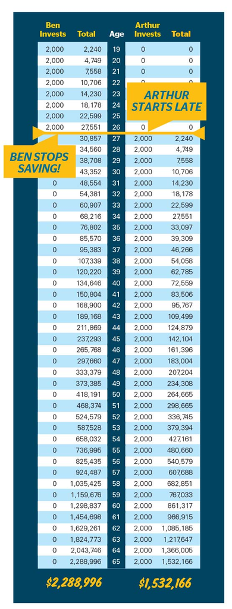

# Tips

Never get a car loan. Buy in cash. Instead of making a car payment to the bank, delay purchasing it and make a car payment to yourself.

Food budget: people blow their budgets on food again and again. If you buy food at the grocery store etc., you save a ton of money. Talk to the families in the church and have them teach you their favorite dish.

# Places to look in the scriptures about money

- Matthew
- Luke
- Proverbs